# Lab 4: Linear and Logistic regression

Jen Townsend

June 13, 2021

# Goals:

In this lab you will review, learn from, and improve on models built via linear regression and logistic regression. At the end, you should:

- Understand how to use linear regression in R to output the coefficients for a prediction model like
  $$Y \approx \beta_0 + \beta_1 \cdot X_1 +\beta_2 \cdot X_2 + \ldots$$
- Know that you can use boolean indicator variables to encode non-numeric factors for use in a regression.
- Understand how to interpret the “summary” of a model built in R including:
  - coefficients and their statistical significance as built up from the standard error, t-value, and finally p-value
  - R-squared (in a linear regression) – if this is small (e.g. < 0.6) the model is not very reliable for using for predictions.
- Use the linear model (and `predict` method) in R to apply the model and compare predictions to the actual values.
- Understand that logistic regression is used to predict a boolean (yes/no) output.
- Be able to build a logistic regression, interpret the summary, and use the model for predictions.
- Measure the accuracy of a logistic regression based on the % of data points it is accurate for.

# Task 1: Linear regression

Linear regression is used to **predict a NUMERIC output variable** (like a person’s height, income, or the number of songs they’ll listen to in your app) when there are other factors that have a strong relationship with the variable you are trying to predict.

In this task I’ll give a demo of usage of linear regression in R, and ask you to answer questions along the way. Then you’ll try to best the model we construct.

Our goal: to try to predict the annual medical costs for each person (as billed by health insurance) as a function of several factors including age, sex, BMI, # of dependents, whether the person smokes, and the region of the US they live in.

### Step 0: download and review data

Download the InsuranceData file and run the following code (also remove the eval=FALSE so these render in your knit html!!!)

```r
# add the line to import the InsuranceData.csv file
insurance <- read.csv("C:/Users/seven/Desktop/Bellevue College/Math270/Lab4/insurance.csv")

head(insurance)
```

```
##   age    sex    bmi children smoker    region   charges
## 1  19 female 27.900        0    yes southwest 16884.924
## 2  18   male 33.770        1     no southeast  1725.552
## 3  28   male 33.000        3     no southeast  4449.462
## 4  33   male 22.705        0     no northwest 21984.471
## 5  32   male 28.880        0     no northwest  3866.855
## 6  31 female 25.740        0     no southeast  3756.622
```

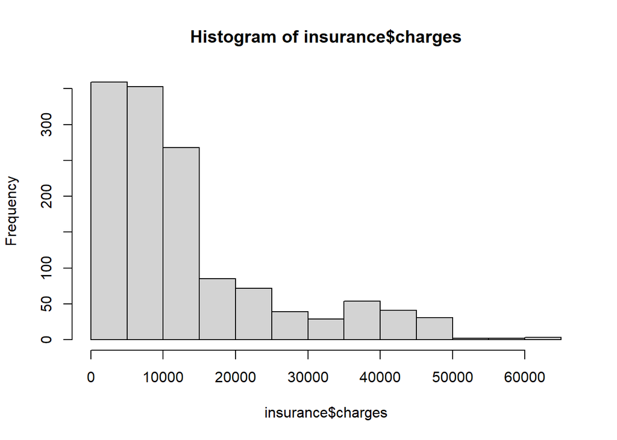

```r
hist(insurance$charges)
```

As an observation, if I know *nothing* about an individual, I might predict their Insurance charges to be $13,270.42 (the average), but I’d expect that to be pretty far off from each individual’s value.

```r
mean(insurance$charges)
```

```
## [1] 13270.42
```

Let’s check a few factors to see if they have strong relationships with the insurance charges

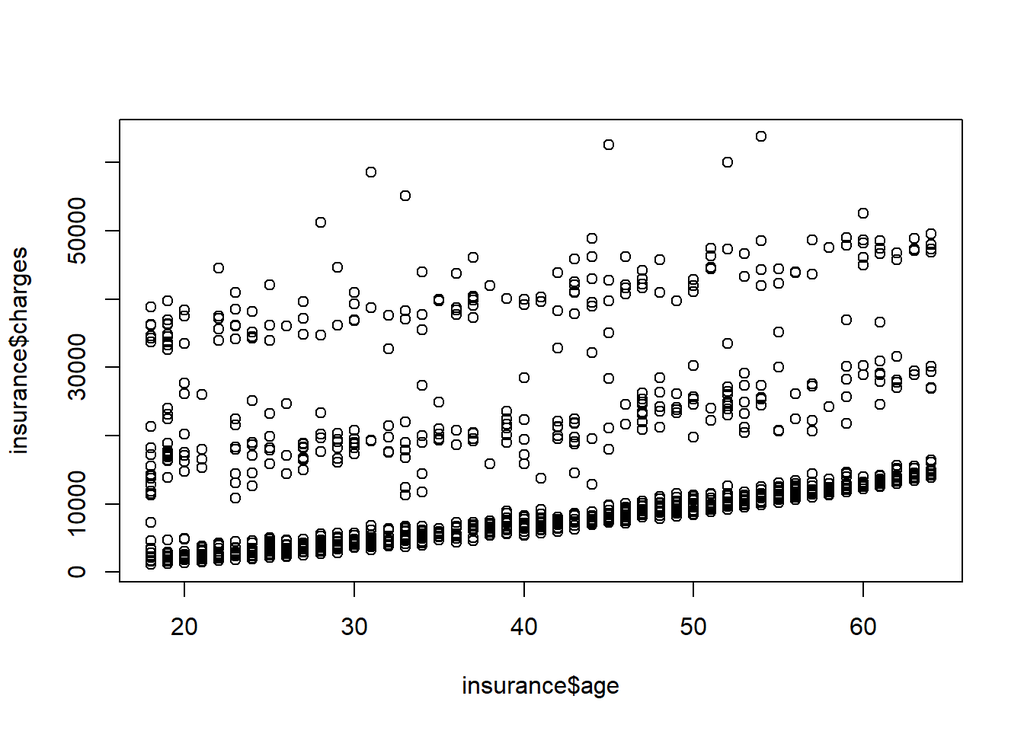

```r
plot(insurance$age, insurance$charges)
```

Interesting! (there seems to be a relationship, but it also looks like there are 3 different groupings!?)

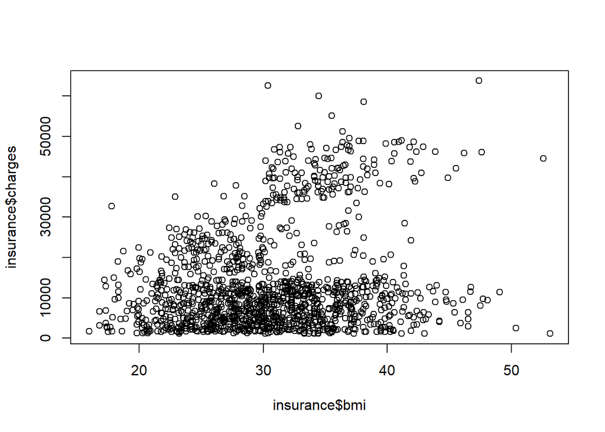

```r
plot(insurance$bmi, insurance$charges)
```

Hmmm..this relationship isn’t super clear.

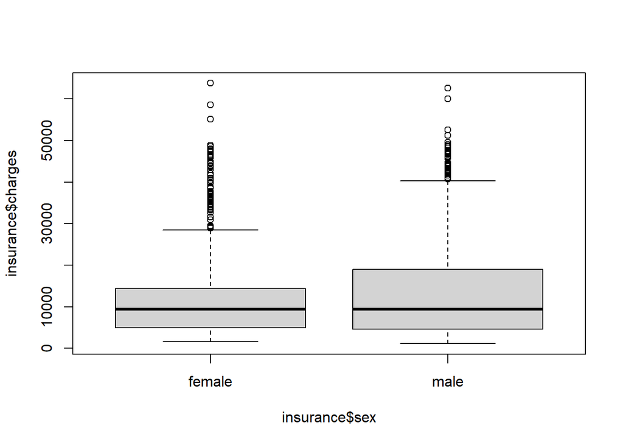

```r
boxplot(insurance$charges ~insurance$sex)
```

It looks like the median cost is about the same for male and female, based on the 75th percentile and top, more males have higher changes.

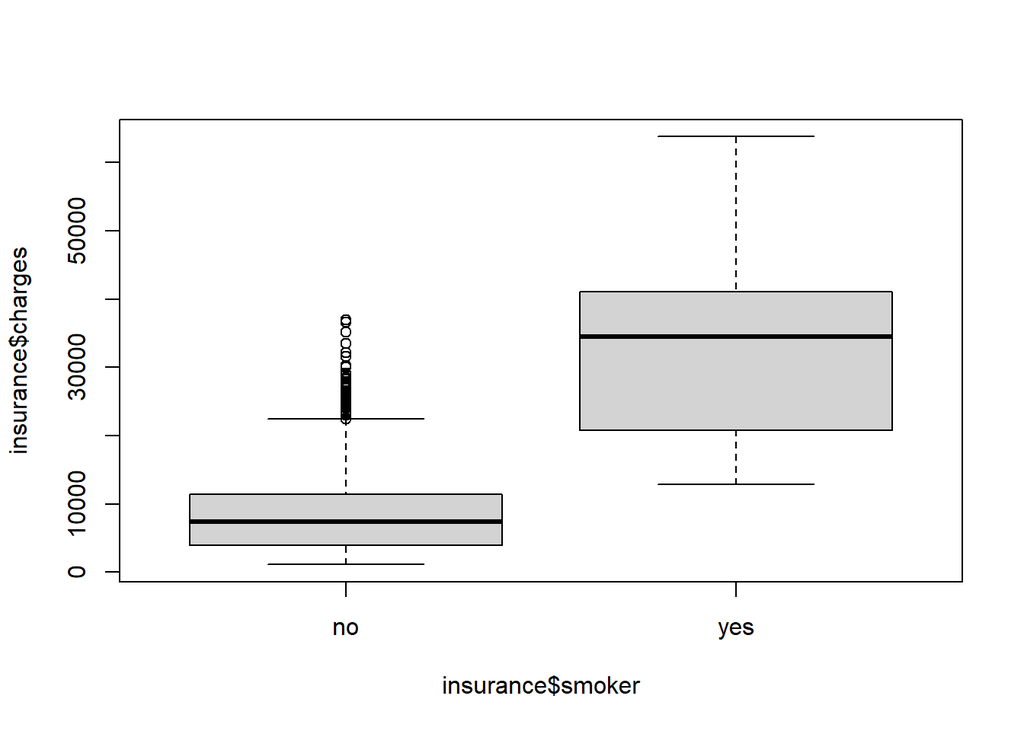

```r
boxplot(insurance$charges ~insurance$smoker)
```

Wow! Looks like a very strong relationship between smoking and higher medical charges.

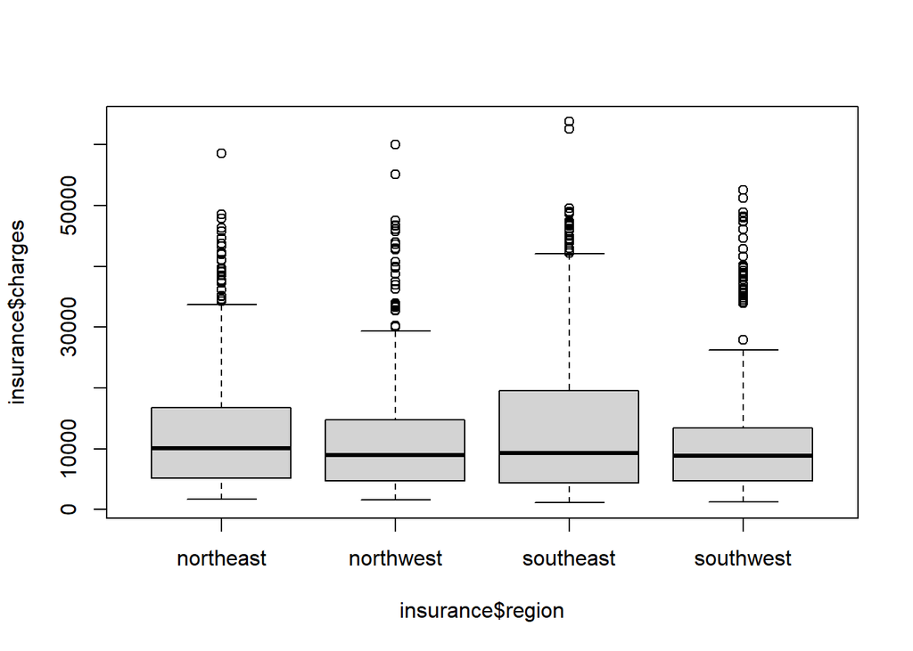

```r
boxplot(insurance$charges~insurance$region)
```

Hmm… all the regions have roughly the same median, though some (e.g. southeast) seem to have more individuals with high charges.

# Step 1: reserve some “testing” data

Normally we’d reserve a big testing set. You’ll do this in the logistic regression task. For this example, I’ll just take a couple data points and pull them out of the full data set:

```r
set.seed(50)
testIndices = sample(nrow(insurance),5)

reservedInsuranceForTesting = insurance[testIndices,] # set aside some test rows of data

InsuranceData = insurance[-testIndices,] # remove the test indices from the training data set
```

## Example 1: a simple linear model using the lm (linear model) function.

To start with, let’s try to predict the charges JUST based on age:

```r
insurance.lm.age_only <- lm(charges ~ age, data = InsuranceData)
```

We can plot this:

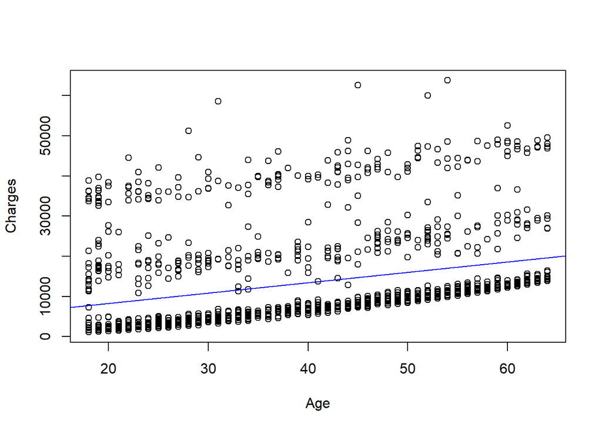

```r
plot(InsuranceData$charges ~ InsuranceData$age, xlab="Age", ylab="Charges")
abline(insurance.lm.age_only, col="blue")
```

It mainly fits the slope… but since there are kind of 3 main lines it doesn’t seem to fit the data particularly well. To get a sense of this, let’s review the “summary” of the model:

```r
summary(insurance.lm.age_only)
```

```
##
## Call:
## lm(formula = charges ~ age, data = InsuranceData)
##
## Residuals:
##    Min     1Q Median     3Q    Max
##  -8021  -6622  -5901   5391  47861
##
## Coefficients:
##             Estimate Std. Error t value Pr(>|t|)
## (Intercept)  3079.90     933.62   3.299 0.000996 ***
## age           258.92      22.41  11.556  < 2e-16 ***
## ---
## Signif. codes:  0 '***' 0.001 '**' 0.01 '*' 0.05 '.' 0.1 ' ' 1
##
## Residual standard error: 11490 on 1331 degrees of freedom
## Multiple R-squared:  0.09118,    Adjusted R-squared:  0.0905
## F-statistic: 133.5 on 1 and 1331 DF,  p-value: < 2.2e-16
```

### How do we interpret the model summary?

**Residuals:** This gives a summary of how “bad” the model’s predictions are on the training data by looking at residual error (actual charge - predicted charge). It reports min, 25th percentile, 50th percentile, 75th percentile, and max residual.

Ideally the median would be around 0 (1/2 data points are overestimated, 1/2 are underestimated), and the quartiles would be close to 0 as well. In this model, we don’t have that… which generally indicates the model is missing something substantial.

In this case, the min Residual = -$8,021 means that the worst overestimate by the model was $8021 (the actual is that much less than the model). Because the median error is -$5,901, we know that half of the time the model overestimates by at most $5,901. The other half of data points are either underestimates, or overestimated by less than $5,901.

**Table – Coefficients column:**

These are the slope and intercept coefficients $\beta_0,\beta_1$ for the model $\hat{y} = \beta_0 + \beta_1 \cdot x$.

From this, I can tell the model gives the equation:
$$Charges \approx 3079.90 + 258.92 * age$$

Meaning that even for a “0” year old, we’d expect a charge of $ 3,079.90 (note we actually only have data for people who are 18+ in age).

And on average, each additional year of age leads to an estimated increase of $ 258.92.

So for someone who is 30 years old, using our model we’d predict they’d have $10,847.5 in insurance charges.

**Table – Std. Error column:**

This is the standard error of the coefficient and gives a sense of how much we might expect the coefficient estimates to change if we had taken a different sample instead.

We can see that the age coefficient (estimated at 258.92 from this particular data sample) has a standard error of around $\pm 22.41$ – so that coefficient could very easily be anywhere between e.g. 236.51 and 281.33, but is very unlikely to be -50 (since that would be 13 SE away from the measured estimate!).

**Table – t-value column:**

(aka z-score) This gives the # of SE the coefficient is from 0. So, for example the intercept estimate of 3079.90 has SE=933.62. this means that t or z score will be: $z = \frac{3079.9 - 0 }{933.62} \approx 3.299$.

Remember: if the estimate is within one or two SE of 0, that “0” is within the error bounds from the measured value.

**Table – Pr(>|t|) column:**

This is the p-value! What is the probability of getting a sampled estimate at least this many SE from 0, if the “true” value is 0?

Tiny p-values (which happen for big t-values) indicate the data is strong evidence the particular coefficient is NOT 0 – so the factor is useful in predicting the overall outcome.

Here age (and the intercept) are both found to be stat-sig in their assistance to predict the insurance cost.

**Other summary contents:**

`Residual standard error: 11490 on 1331 degrees of freedom.`

Residual standard error captures: how much do the residuals vary? Ideally this is pretty small (meaning the residuals tend to be close to 0). Here it is not, indication the model has a lot of room to improve!

This is approximately the standard deviation of residuals: `sd(insurance.lm.age_only$residuals) = 11489.37`, its off by a bit because of an adjustment from “degrees of freedom” (which is # rows of data - # coefficients in the model).

`Multiple R-squared: 0.09118, Adjusted R-squared: 0.0905`

These are “R-squared” values, also known as the “coefficient of determination”. Generally, we want these to be as close to 1 as possible. $R^2$ is computed directly by taking $1- Var(\epsilon)/Var(Y)$, when $\epsilon$ represents the residuals, and $Y$ represents the value you are trying to predict (here insurance charges):

```r
epsilon = insurance.lm.age_only$residuals
Y = InsuranceData$charges
Rsq = 1 - var(epsilon) / var(Y)
Rsq
```

```
## [1] 0.09118059
```

This tells us “out of all the original 100% of variance in insurance charges, how much is explained by our model?” This is why we want it to be big: we want the model to explain most of how the output variable changes for each person!

Here $R^2$ is only about 9% of the variance in insurance charges is explained by taking age into account. So we have about 91% of the differences in insurance charges unexplained still!

How about the adjusted R-squared? It adjusts for the fact that adding variables skews this, and is a “corrected” version that is a bit more reliable. You can interpret it in the same way, otherwise.

`F-statistic: 133.5 on 1 and 1331 DF, p-value: < 2.2e-16` The F-statistic is kind of like a t-score, but for the overall model compared to just using the “naive” prediction of predicting everyone as the average. Here we can just rely on the p-value, which by being so small indicates this model is a statistically significant improvement over the naive prediction.

### Using the model

Even though this isn’t a GOOD model, I’ll demonstrate how to use the model to predict data points using the `predict(model, dataToPredictFrom, optionalArguments)` method

```r
chargePrediction = predict(insurance.lm.age_only, reservedInsuranceForTesting, interval = "prediction", level=0.99)

cbind(actual = reservedInsuranceForTesting$charges, chargePrediction)
```

```
##         actual       fit       lwr      upr
## 11    2721.321  9552.991 -20117.80 39223.78
## 820  55135.402 11624.381 -18037.20 41285.96
## 1119 38282.749 11624.381 -18037.20 41285.96
## 863  12269.689 17320.705 -12352.69 46994.10
## 882   2789.057  9035.143 -20639.08 38709.36
```

Here the first column I set up as the actual charge for the data set, while the “fit” column is the prediction. You can see we have some REALLY bad guesses. Most do tend to be in between the “lwr” and “upr” guesses – but more because those are HUGE (and so not very useful) ranges rather than because our guesses are accurate.

## Example 1.b – let’s add another variable! (also: indicator variable!)

Let’s build a model for predicting insurance charges that relies on both age and “smoker” status.

But “smoker” is not numeric! How can we find a “coefficient” on it?

Simple: we can treat it as a binary 0,1 variable. Encode everyone who is a smoker as “1” and everyone who is not as a “0” in this column.

e.g:

```r
smokerIndicator = ifelse(InsuranceData$smoker == "yes" , 1 , 0)

InsuranceDataWithSmokeIndicator = cbind(InsuranceData, smokerIndicator)
head(InsuranceDataWithSmokeIndicator)
```

```
##   age    sex    bmi children smoker    region   charges smokerIndicator
## 1  19 female 27.900        0    yes southwest 16884.924               1
## 2  18   male 33.770        1     no southeast  1725.552               0
## 3  28   male 33.000        3     no southeast  4449.462               0
## 4  33   male 22.705        0     no northwest 21984.471               0
## 5  32   male 28.880        0     no northwest  3866.855               0
## 6  31 female 25.740        0     no southeast  3756.622               0
```

Now this “smokerIndicator” column is numeric – and the coefficient will give the extra charge expected if someone is a smoker (e.g. if the coefficient for smoker is $1,000, it would mean smokers on average have $1,000 higher medical charges).

**The use of “boolean indicators (0,1)” like we did above is a super common trick for incorporating categories into a regression**

Here’s that model:

```r
insurance.lm<-lm(charges ~ age + smokerIndicator  , data=InsuranceDataWithSmokeIndicator)

summary(insurance.lm)
```

```
##
## Call:
## lm(formula = charges ~ age + smokerIndicator, data = InsuranceDataWithSmokeIndicator)
##
## Residuals:
##      Min       1Q   Median       3Q      Max
## -15968.9  -2051.3  -1344.6   -206.4  28875.4
##
## Coefficients:
##                 Estimate Std. Error t value Pr(>|t|)
## (Intercept)     -2409.85     526.96  -4.573 5.25e-06 ***
## age               275.41      12.42  22.175  < 2e-16 ***
## smokerIndicator 23733.67     432.99  54.813  < 2e-16 ***
## ---
## Signif. codes:  0 '***' 0.001 '**' 0.01 '*' 0.05 '.' 0.1 ' ' 1
##
## Residual standard error: 6369 on 1330 degrees of freedom
## Multiple R-squared:  0.7211, Adjusted R-squared:  0.7207
## F-statistic:  1720 on 2 and 1330 DF,  p-value: < 2.2e-16
```

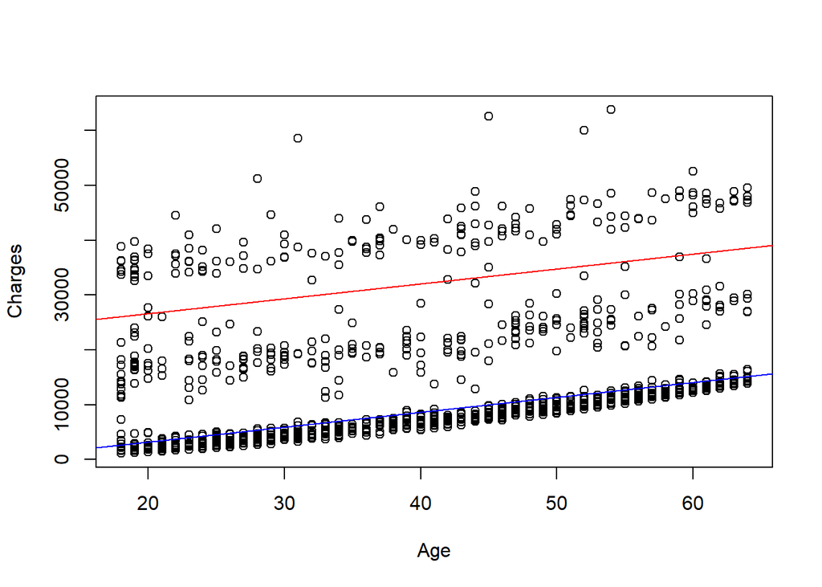

```r
plot(InsuranceData$charges ~ InsuranceData$age, xlab="Age", ylab="Charges")
abline(-2224.24,271.11, col="blue") #nonsmokers
abline(21236.69,271.11, col="red") # smokers
```

Interesting! the blue line seems to fit the lower charges group, while the red seems to be central to the other two groups.

### How much have we improved our predictions by adding the smoker indicator?

```r
summary(insurance.lm)
```

```
##
## Call:
## lm(formula = charges ~ age + smokerIndicator, data = InsuranceDataWithSmokeIndicator)
##
## Residuals:
##      Min       1Q   Median       3Q      Max
## -15968.9  -2051.3  -1344.6   -206.4  28875.4
##
## Coefficients:
##                 Estimate Std. Error t value Pr(>|t|)
## (Intercept)     -2409.85     526.96  -4.573 5.25e-06 ***
## age               275.41      12.42  22.175  < 2e-16 ***
## smokerIndicator 23733.67     432.99  54.813  < 2e-16 ***
## ---
## Signif. codes:  0 '***' 0.001 '**' 0.01 '*' 0.05 '.' 0.1 ' ' 1
##
## Residual standard error: 6369 on 1330 degrees of freedom
## Multiple R-squared:  0.7211, Adjusted R-squared:  0.7207
## F-statistic:  1720 on 2 and 1330 DF,  p-value: < 2.2e-16
```

All the coefficients are statistically significant (indicating they are all useful for improving our prediction), and the R-squared has jumped to over 70% of the variance in charge now explained in the model! Excellent!!

[Note: R actually will automatically treat string columns as factors, so if you are careful with it, you can just use the original smoker column as a factor]